# Práctica 3.1: Regresión lineal

Ahora se va a realizar la estimación del modelo, separando datos de entrenamiento y datos de test.

```python
from sklearn.model_selection import train_test_split
SEED_VALUE = 123  # NON CAMBIES ESTE SEED, así todos teremos os mesmos resultados

np.random.seed(SEED_VALUE)
cereal_train, cereal_test = train_test_split(cereal, test_size=0.3, random_state=SEED_VALUE)

print('Tamaño train: {}'.format(cereal_train.shape[0]))
print('Tamaño test: {}'.format(cereal_test.shape[0]))

# Dividimos o dataset en variables predictoras e dependentes
cereal_train_X = cereal_train.loc[:,['sugars', 'fiber']].astype(float)
cereal_train_Y = cereal_train.loc[:, 'rating']

model = LinearRegression()  # Definimos o modelo
np.random.seed(SEED_VALUE)
model.fit(cereal_train_X, cereal_train_Y)  # Axustamos o modelo aos datos

# Resumo do modelo
coef = pd.DataFrame([model.intercept_, *model.coef_], ['(Intercept)', *cereal_train_X.columns], columns=['Coefficients'])
coef
```

```
Tamaño train: 53
Tamaño test: 24
```

|  | Coefficients |
| --- | --- |
| (Intercept) | 51.024118 |
| sugars | -2.094388 |
| fiber | 2.877667 |

Como se puede observar, los datos de intercepto y los incremento por unidad de sugars y fiber varían ligeramente con respecto a cuando el modelo se construyó con los 77 datos. A continuación se calculará las predicciones con los datos de test.

```python
# Dividimos o dataset en variables predictoras e dependentes
cereal_test_X = cereal_test.loc[:, ['sugars', 'fiber']].astype(float)
cereal_test_Y = cereal_test.loc[:, 'rating']

np.random.seed(SEED_VALUE)
predicions = model.predict(cereal_test_X)


def h(x1,x2, th0, th1,th2):
    return (th0 + x1 * th1 + x2 * th2)


predicions2 = h(cereal_test_X['sugars'].values, cereal_test_X['fiber'].values,th0=coef['Coefficients']['(Intercept)'], th1=coef['Coefficients']['sugars'],
             th2=coef['Coefficients']['fiber'])


print('Predicións obtidas coa función .predict():')
print(predicions)
print()
print('Predicións obtidas coa función h:')
print(predicions2)

### Erro cadrático medio ###
def ecm(reais, predicion):
    m = len(reais)  # tamaño do conxunto de datos
    erro = sum((predicion - reais)**2) / (2*m)
    return erro


e_cadratico = ecm(cereal_test_Y, predicions)
print(e_cadratico)
np.sqrt(e_cadratico)
```

```
Predicións obtidas coa función .predict():
[47.61862147 62.53478448 33.21335745 37.14668325 44.21312523 43.42984618
 25.89146598 46.83534243 49.96845861 53.37395485 54.94051294 53.37395485
 36.61885369 26.67474502 37.14668325 59.65711779 53.37395485 44.74095478
 34.3967413  40.02434994 27.98585362 36.61885369 40.27979943 32.17462891]

Predicións obtidas coa función h:
[47.61862147 62.53478448 33.21335745 37.14668325 44.21312523 43.42984618
 25.89146598 46.83534243 49.96845861 53.37395485 54.94051294 53.37395485
 36.61885369 26.67474502 37.14668325 59.65711779 53.37395485 44.74095478
 34.3967413  40.02434994 27.98585362 36.61885369 40.27979943 32.17462891]
15.901952383285057
```

```
3.9877252141145654
```

Como se puede observar, se obtienen las mismas predicciones con el modelo lineal que la función h definida anteriormente. Además, la raíz error cuadrático medio es de 3.98, lo que es un valor pequeño, que indica la obtención de un buen modelo.

```python
cereal_test_Y.corr(pd.Series(predicions, cereal_test_Y._index))
```

```
0.8992759511102486
```

También se puede ver utilizando el coeficiente de correlacion entre los datos predecidos y los test, la cual es de 0.89 (muy próxima a 1), por lo que indica que la predicción es buena. Los métodos vistos para el análisis y detección de valores outliers no permiten realizarlo sobre un modelo de regresión múltiple, con dos variables predictoras, por lo que no se va realizar la parte de eliminación de dichos valores y observación de mejora del modelo, pero sí se va a eliminar un dato de sugars que puede estar distorsian. Aún así, se aporta un pequeño análisis acerca de los posibles valores outliers de las variables univariantes.

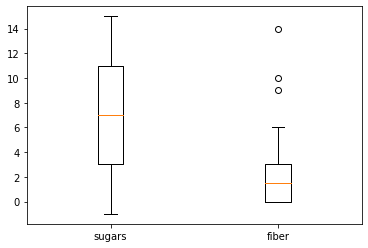

```
Outliers na variable 'sugar': []
Outliers na variable 'fiber': [10. 14.  9.]
```

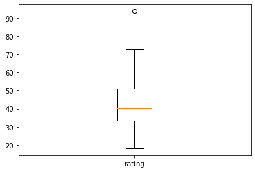

```
Outliers na variable 'rating': [93.704912]
```

```python
  box = plt.boxplot(cereal_train.loc[:,['sugars','fiber']], labels = ['sugars','fiber'])
plt.show()

out_sugar = box["fliers"][0].get_data()[1]
out_fiber = box["fliers"][1].get_data()[1]


print("Outliers na variable 'sugar': {}".format(out_sugar))
print("Outliers na variable 'fiber': {}".format(out_fiber))



box = plt.boxplot(cereal_train.loc[:,['rating']], labels = ['rating'])
plt.show()
out_rating = box["fliers"][0].get_data()[1]
print("Outliers na variable 'rating': {}".format(out_rating))
```

Como se puede observar, hay un valor en sugars, con valor de -1, que no tiene sentido en el modelo, ya que no puede haber un dato negativo, por lo que se eliminará del modelo. Por otro lado, en sugars no se observa ningún valor de outlier, mientras que en fiber y rating si que se observan. Pero estos son datos que se observan univariantemente, que pueden tener un análisis distinto en el modelo multivariante. Como los métodos aportados en esta práctica para la visualización de datos outliers solo permite realizarlo con una única variable en el eje X y una en el eje Y, siendo un gráfico bidimensional, no se va a realizar la detección de valores outliers gráficamente. Sin embargo, se va a eliminar el dato erróneo en sugars para ver cómo varía el modelo. Como tienen que tener la misma dimensión, se eliminan los datos tanto de sugars como de fiber y rating, para obtener el modelo.

```python
# Identificar y eliminar filas con 'sugars' igual a -1 en cereal_train_X
cereal_train_X_new = cereal_train_X[cereal_train_X['sugars'] != -1]

# Correspondientemente, eliminar las mismas filas en cereal_train_Y
cereal_train_Y_new = cereal_train_Y[cereal_train_X['sugars'] != -1]

#Se comprueba que están bien los datos
cereal_train_X_new.describe()
cereal_train_Y_new.describe()
```

```
count    52.000000
mean     42.621477
std      14.771649
min      18.042851
25%      32.739564
50%      40.253086
75%      51.092973
max      93.704912
Name: rating, dtype: float64
```

```python
new_model = LinearRegression()  # Definimos un novo modelo
new_model.fit(cereal_train_X_new, cereal_train_Y_new)  # Axustamos o novo modelo aos datos

# Resumo do modelo
new_coef = pd.DataFrame([new_model.intercept_, *new_model.coef_], ['(Intercept)', *cereal_train_X_new.columns], columns=['Coefficients'])
new_coef
```

|  | Coefficients |
| --- | --- |
| (Intercept) | 51.796903 |
| sugars | -2.174235 |
| fiber | 2.871079 |

```python
predicions = model.predict(cereal_test_X)
e_cadratico_new = ecm(cereal_test_Y, predicions)
print(e_cadratico)
print(e_cadratico_new)
np.sqrt(e_cadratico_new)
print(e_cadratico-e_cadratico_new)
```

```
15.901952383285057
15.901952383285057
0.0
```

De este modo, se concluye que el modelo de predicción multivariante con las variables sugars y fiber es un buen modelo (coeficiente de correlación de 0.8992759511102486 utilizando las variables test), por lo que podría usuarse para predecir el rating de los cereales, teniendio en cuenta los valores de sugars y fiber.